# Capstone Project: Air Quality Data Exploration

Ceren Ünal

# 1 Import Data

```r
air.tbl <- as_tibble(airquality) #local copy created as tibble

class(air.tbl) #class confirmed
```

```
## [1] "tbl_df"     "tbl"        "data.frame"
```

## 1.1 About the data set

```r
?airquality #access help article
```

```
## starting httpd help server ... done
```

This data set contains the daily air quality measurements in New York, from May to September 1973.

In this project, we will be treating Ozone as a dependent variable and the Solar.R, Wind, and Temp as independent variables. There is also the Month variable in the data set, which may be a moderating factor.

Our hypotheses are as follows.

H1: Ozone amount will be associated positively with Solar radiation amount (Solar.R)  
H2: Ozone amount will be associated negatively with Wind speed (Wind)  
H3: Ozone amount will be associated positively with Maximum daily temperature (Temp)  
H4: Ozone amount will be highest during summer months.

# 2 Problem 1: Explore Data

```r
dim(air.tbl) #get row and column numbers
```

```
## [1] 153   6
```

There are 153 observations and 6 variables.

```r
glimpse(air.tbl)
```

```
## Rows: 153
## Columns: 6
## $ Ozone   <int> 41, 36, 12, 18, NA, 28, 23, 19, 8, NA, 7, 16, 11, 14, 18, 14, …
## $ Solar.R <int> 190, 118, 149, 313, NA, NA, 299, 99, 19, 194, NA, 256, 290, 27…
## $ Wind    <dbl> 7.4, 8.0, 12.6, 11.5, 14.3, 14.9, 8.6, 13.8, 20.1, 8.6, 6.9, 9…
## $ Temp    <int> 67, 72, 74, 62, 56, 66, 65, 59, 61, 69, 74, 69, 66, 68, 58, 64…
## $ Month   <int> 5, 5, 5, 5, 5, 5, 5, 5, 5, 5, 5, 5, 5, 5, 5, 5, 5, 5, 5, 5, 5,…
## $ Day     <int> 1, 2, 3, 4, 5, 6, 7, 8, 9, 10, 11, 12, 13, 14, 15, 16, 17, 18,…
```

All of our variables are numeric, though Month and Day variables may work better as a factor. At a quick glance, we can see that there are several missing values in Ozone and Solar Radiaiton columns.

## 2.1 Simple Descriptive statistics

```r
summary(air.tbl) #summary stats
```

```
##      Ozone           Solar.R           Wind             Temp
##  Min.   :  1.00   Min.   :  7.0   Min.   : 1.700   Min.   :56.00
##  1st Qu.: 18.00   1st Qu.:115.8   1st Qu.: 7.400   1st Qu.:72.00
##  Median : 31.50   Median :205.0   Median : 9.700   Median :79.00
##  Mean   : 42.13   Mean   :185.9   Mean   : 9.958   Mean   :77.88
##  3rd Qu.: 63.25   3rd Qu.:258.8   3rd Qu.:11.500   3rd Qu.:85.00
##  Max.   :168.00   Max.   :334.0   Max.   :20.700   Max.   :97.00
##  NA's   :37       NA's   :7
##      Month            Day
##  Min.   :5.000   Min.   : 1.0
##  1st Qu.:6.000   1st Qu.: 8.0
##  Median :7.000   Median :16.0
##  Mean   :6.993   Mean   :15.8
##  3rd Qu.:8.000   3rd Qu.:23.0
##  Max.   :9.000   Max.   :31.0
##
```

Ozone has 37 NA values, while Solar R has 7. Summary stats are unnecessarily being calculated for Month and Day due to them being numeric.

```r
skimr::skim(air.tbl)
```

Data summary

| Name | air.tbl |
| --- | --- |
| Number of rows | 153 |
| Number of columns | 6 |
| _______________________ |  |
| Column type frequency: |  |
| numeric | 6 |
| ________________________ |  |
| Group variables | None |

**Variable type: numeric**

| skim_variable | n_missing | complete_rate | mean | sd | p0 | p25 | p50 | p75 | p100 | hist |
| --- | --- | --- | --- | --- | --- | --- | --- | --- | --- | --- |
| Ozone | 37 | 0.76 | 42.13 | 32.99 | 1.0 | 18.00 | 31.5 | 63.25 | 168.0 | ▇▃▂▁▁ |
| Solar.R | 7 | 0.95 | 185.93 | 90.06 | 7.0 | 115.75 | 205.0 | 258.75 | 334.0 | ▅▃▅▇▅ |
| Wind | 0 | 1.00 | 9.96 | 3.52 | 1.7 | 7.40 | 9.7 | 11.50 | 20.7 | ▂▇▇▃▁ |
| Temp | 0 | 1.00 | 77.88 | 9.47 | 56.0 | 72.00 | 79.0 | 85.00 | 97.0 | ▂▃▇▇▃ |
| Month | 0 | 1.00 | 6.99 | 1.42 | 5.0 | 6.00 | 7.0 | 8.00 | 9.0 | ▇▇▇▇▇ |
| Day | 0 | 1.00 | 15.80 | 8.86 | 1.0 | 8.00 | 16.0 | 23.00 | 31.0 | ▇▇▇▇▆ |

The Ozone variable has a severely right skewed histogram. Solar R is also far from normal distribution.

```r
length(unique(air.tbl$Month)) #count unique values
```

```
## [1] 5
```

```r
length(unique(air.tbl$Day))
```

```
## [1] 31
```

There are 5 unique values for Month and 31 for Day. No missing dates.

We will be assigning Month and Day as factors ahead of further exploration.

```r
air.tbl$Month <- as.factor(air.tbl$Month) #covert column to factor
air.tbl$Day <- as.factor(air.tbl$Day) #covert column to factor

air.tbl
```

```
## # A tibble: 153 × 6
##    Ozone Solar.R  Wind  Temp Month Day
##    <int>   <int> <dbl> <int> <fct> <fct>
##  1    41     190   7.4    67 5     1
##  2    36     118   8      72 5     2
##  3    12     149  12.6    74 5     3
##  4    18     313  11.5    62 5     4
##  5    NA      NA  14.3    56 5     5
##  6    28      NA  14.9    66 5     6
##  7    23     299   8.6    65 5     7
##  8    19      99  13.8    59 5     8
##  9     8      19  20.1    61 5     9
## 10    NA     194   8.6    69 5     10
## # ℹ 143 more rows
```

# 3 Problem 2: Visualize numerical variables

## 3.1 P2.1. Histograms

Ozone is severely right skewed, while Solar R appears to be left skewed.

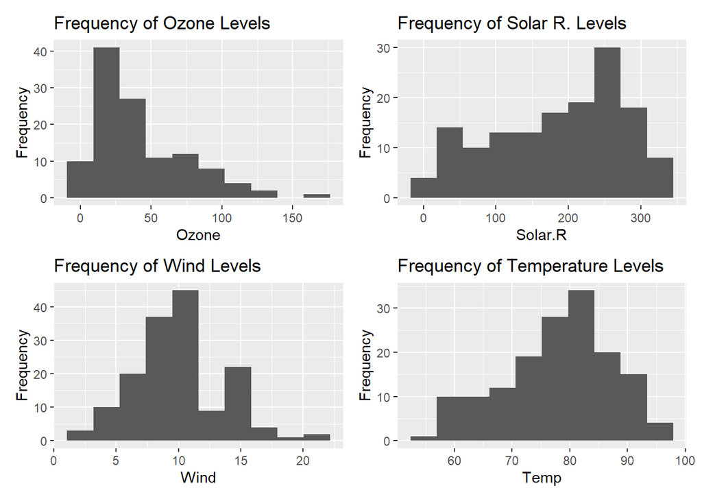

```r
#using patchwork package to combine plots into one layout

p1 <- air.tbl %>%
  ggplot(aes(Ozone)) +
  geom_histogram(bins = 10) +
  #scale_x_log10() +
  labs( title = "Frequency of Ozone Levels", y = "Frequency")


p2 <-  air.tbl %>%
  ggplot(aes(Solar.R)) +
  geom_histogram(bins = 10) +
  labs(title = "Frequency of Solar R. Levels", y = "Frequency")

p3 <- air.tbl %>%
  ggplot(aes(Wind)) +
  geom_histogram(bins = 10) +
  labs(title = "Frequency of Wind Levels", y = "Frequency")

p4 <- air.tbl %>%
  ggplot(aes(Temp)) +
  geom_histogram(bins = 10) +
  labs(title = "Frequency of Temperature Levels", y = "Frequency")

(p1 | p2) / #define the layout
(p3 | p4)
```

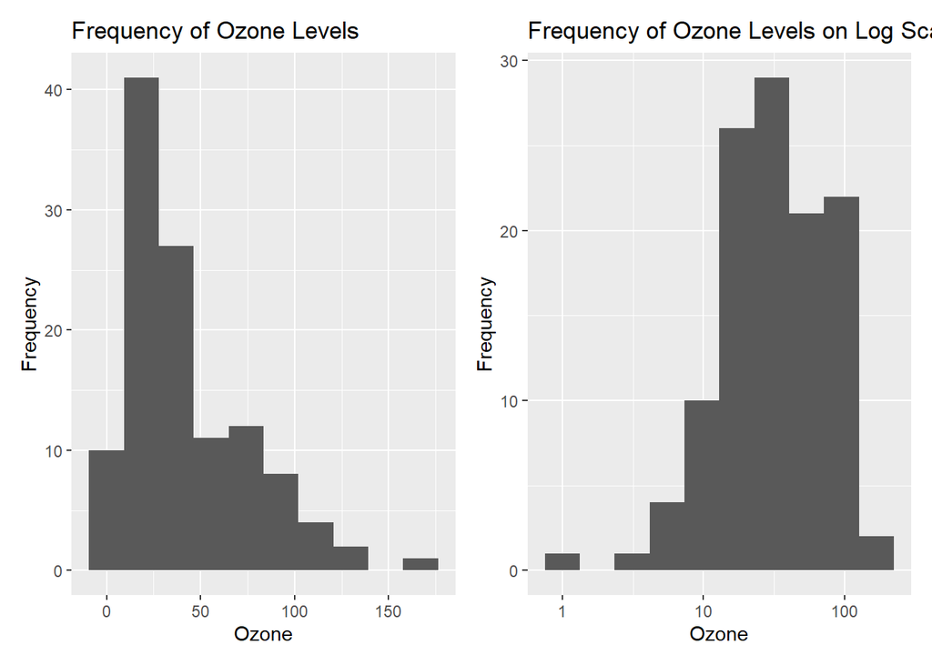

```r
p1_log <- air.tbl %>%
  ggplot(aes(Ozone)) +
  geom_histogram(bins = 10) +
  scale_x_log10() +
  labs( title = "Frequency of Ozone Levels on Log Scale", y = "Frequency")

p1 + p1_log
```

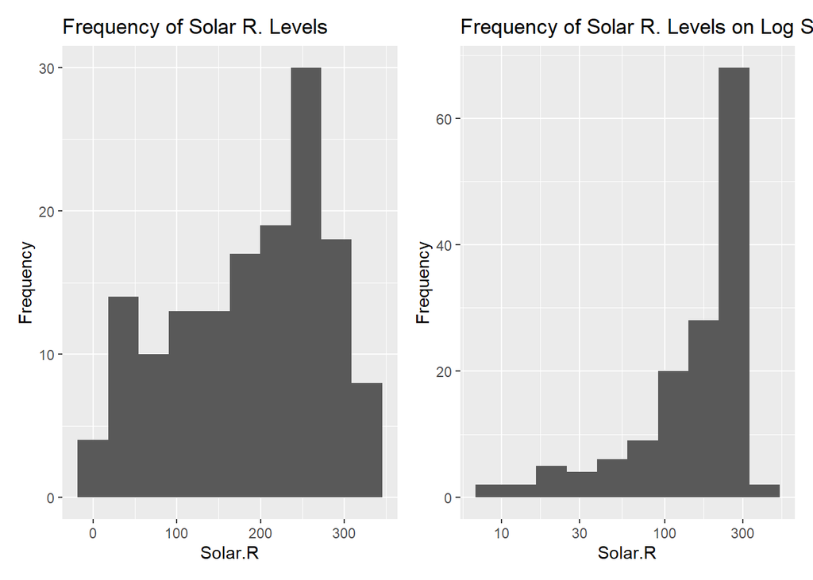

```r
p2_log <- air.tbl %>%
  ggplot(aes(Solar.R)) +
  geom_histogram(bins = 10) +
  scale_x_log10() +
  labs(title = "Frequency of Solar R. Levels on Log Scale", y = "Frequency")

p2 + p2_log
```

## 3.2 P2.2. Ozone by Continuous variables

To visualize the relationship between two continuous variables, we will be using a scatter plot.

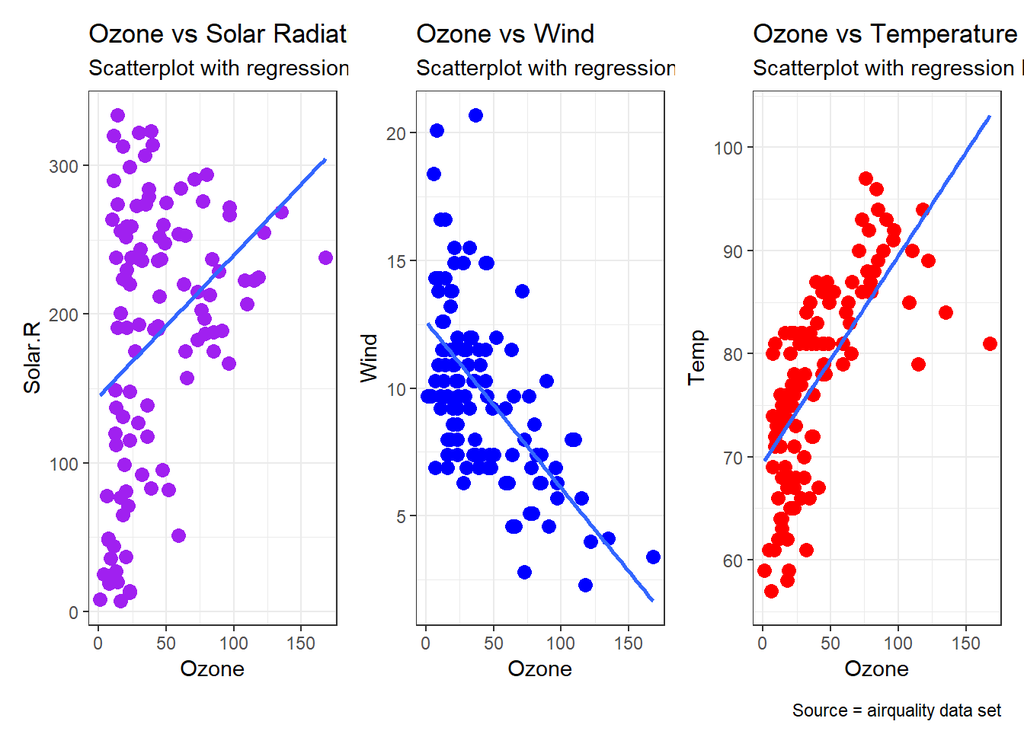

```r
p5 <- air.tbl %>%
ggplot(aes(Ozone, Solar.R)) +
  geom_point(size = 3, color = "purple") +
  geom_smooth(method = lm, se = FALSE) +
  theme_bw() +
  labs (title = "Ozone vs Solar Radiation",
        subtitle = "Scatterplot with regression line")

p6 <- air.tbl %>%
ggplot(aes(Ozone, Wind)) +
  geom_point(size = 3, color = "blue") +
  geom_smooth(method = lm, se = FALSE) +
  theme_bw() +
  labs (title = "Ozone vs Wind",
        subtitle = "Scatterplot with regression line")

p7 <- air.tbl %>%
ggplot(aes(Ozone, Temp)) +
  geom_point(size = 3, color = "red") +
  geom_smooth(method = lm, se = FALSE) +
  theme_bw() +
  labs (title = "Ozone vs Temperature",
        subtitle = "Scatterplot with regression line")

p_all <- p5 + p6 + p7 #collect 3 plots in one plot

p_all + plot_annotation(caption = "Source = airquality data set") #annotate plot and print
```

## 3.3 P2.3. Ozone by Month (Monthly ozone amount)

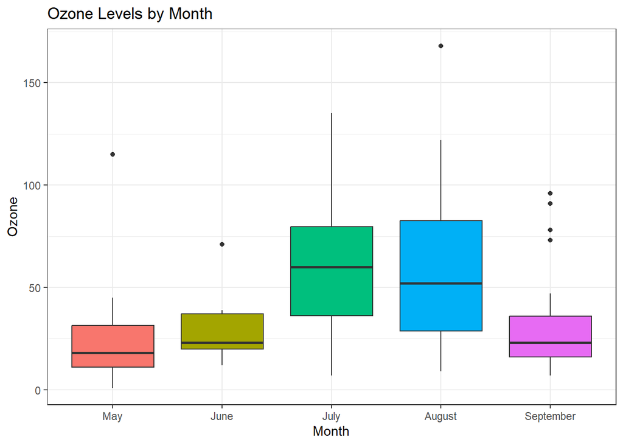

```r
air.tbl %>%
  #drop_na() %>% #remove NA values
   mutate(Month = case_when(Month == 5 ~ "May", #rename values
                           Month == 6 ~ "June",
                           Month == 7 ~ "July",
                           Month == 8 ~ "August",
                           Month == 9 ~ "September"),
         # Month = as.factor(Month), #dropping because we made month into factor before
          Month = fct_relevel(Month, c( #re leveling factors
            "May",
            "June",
            "July",
            "August",
            "September"
          )
          )
          ) %>%
  ggplot(aes(Month, Ozone, fill = Month)) +
  geom_boxplot(show.legend = FALSE)  +
  labs( title = "Ozone Levels by Month") +
  theme_bw()
```

Ozone levels increase in Summer months, namely July and August. Hypothesis 4 is correct.

# 4 Problem 3: The moderating role of the Month

## 4.1 P3.1. How many cases exist for Ozone each month?

```r
air.tbl %>%
  select(Month, Day, Ozone) %>%
  group_by(Month) %>%
  summarise(
    count = n(), #count number of observations in the group
    count_na_rm = sum(!is.na(Ozone))) #count number of observations that are NOT NA
```

```
## # A tibble: 5 × 3
##   Month count count_na_rm
##   <fct> <int>       <int>
## 1 5        31          26
## 2 6        30           9
## 3 7        31          26
## 4 8        31          26
## 5 9        30          29
```

Most of the missing data for Ozone is in June, bbut none of the months seem to have data for all days.

## 4.2 P3.2. Impact of Solar.R on Ozone cut by Month

```r
#renaming and releveling months permanently
air.tbl <- air.tbl %>%
   mutate(Month = case_when(Month == 5 ~ "May", #rename values
                           Month == 6 ~ "June",
                           Month == 7 ~ "July",
                           Month == 8 ~ "August",
                           Month == 9 ~ "September"),
         # Month = as.factor(Month), #this can be dropped because we made it into a factor in a prev step
          Month = fct_relevel(Month, c( #re leveling factors
            "May",
            "June",
            "July",
            "August",
            "September"
          )
          )
          )
```

We have renamed the months for better visualization. Now we can analyze the relationship between Solar R and Ozone moderated by Month.

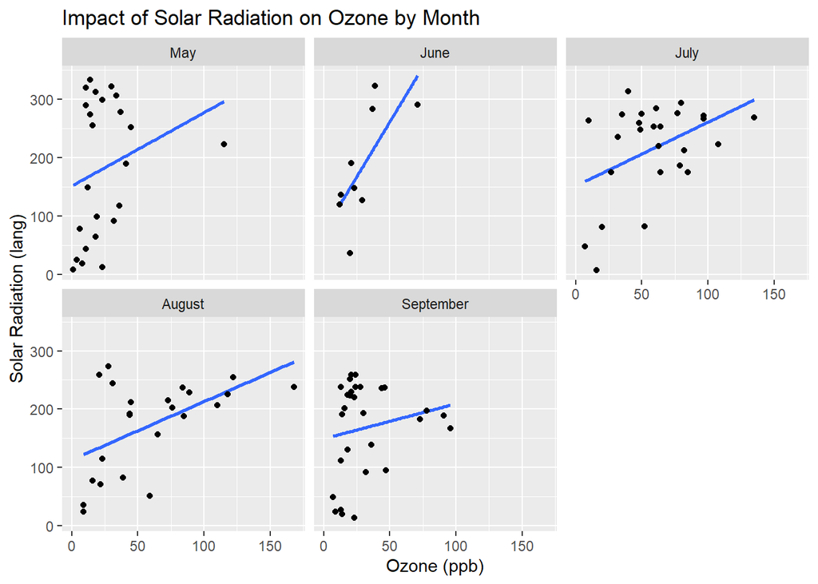

```r
air.tbl %>%
  #drop_na() %>%
  select(Ozone, Solar.R, Month) %>%
  ggplot(aes(Ozone, Solar.R)) +
  facet_wrap(~Month) +
  geom_smooth(method = lm, se = FALSE) +
  geom_point() +
  labs (title = "Impact of Solar Radiation on Ozone by Month",
        y = "Solar Radiation (lang)",
        x = "Ozone (ppb)")
```

## 4.3 P3.3. DImpact of Wind on Ozone cut by Month.

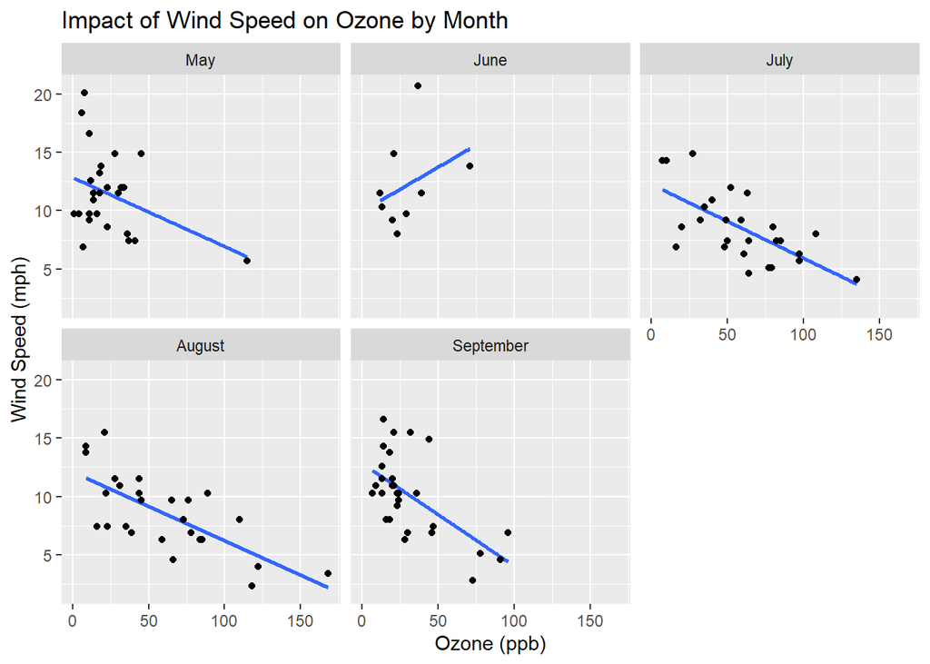

```r
air.tbl %>%
  #drop_na() %>%
  select(Ozone, Wind, Month) %>%
  ggplot(aes(Ozone, Wind)) +
  facet_wrap(~Month) +
  geom_smooth(method = lm, se = FALSE) +
  geom_point() +
  labs (title = "Impact of Wind Speed on Ozone by Month",
        y = "Wind Speed (mph)",
        x = "Ozone (ppb)")
```

## 4.4 P3.4. Impact of Temp on Ozone cut by Month.

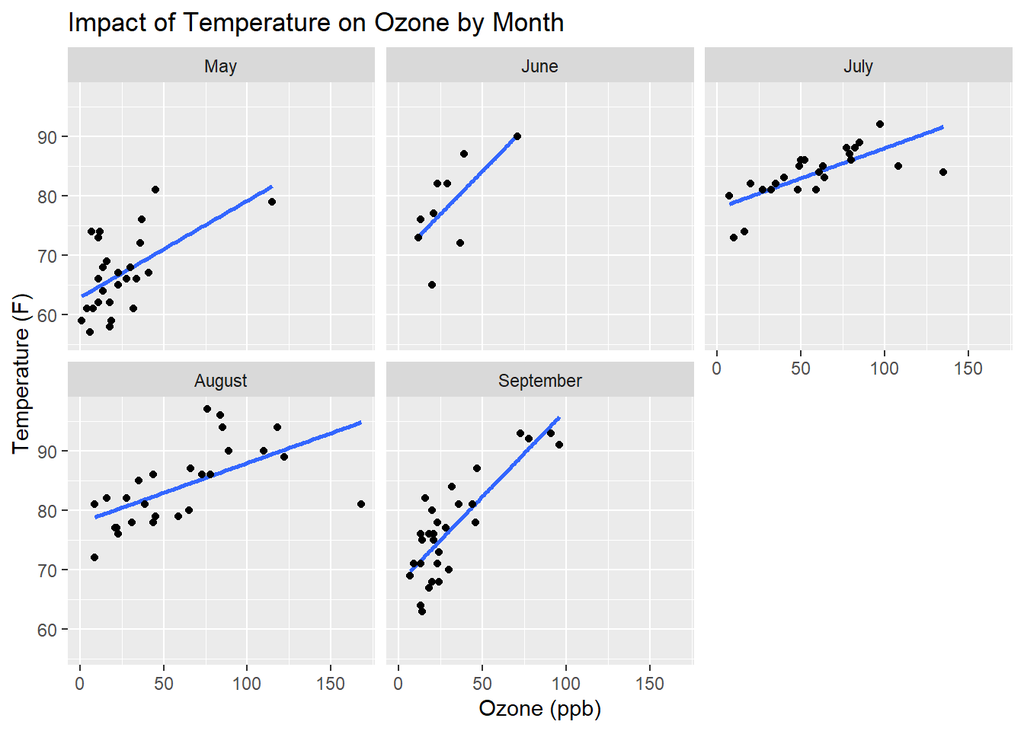

```r
air.tbl %>%
  #drop_na() %>%
  select(Ozone, Temp , Month) %>%
  ggplot(aes(Ozone, Temp)) +
  facet_wrap(~Month) +
  geom_smooth(method = lm, se = FALSE) +
  geom_point() +
  labs (title = "Impact of Temperature on Ozone by Month",
        y = "Temperature (F)",
        x = "Ozone (ppb)")
```

## 4.5 P3.5 Based on the descriptive statistics above, can we conclude that the impact of Solar.R and Wind on Ozone changes by Month?

All months point to positive correlation between Ozone and Solar Radiation.  
On the other hand, all months with the exception of June show negative correlation between Ozone and Wind.  
That being said, the number of observations from June are significantly less than the other months, only 9 observations were recorded. So the contradiction may be due to a lack of data and does not significantly impact the association between Ozone level and Wind Speed.

# 5 Problem 4: Correlations

## 5.1 P4.1. Correlations among all numeric variables

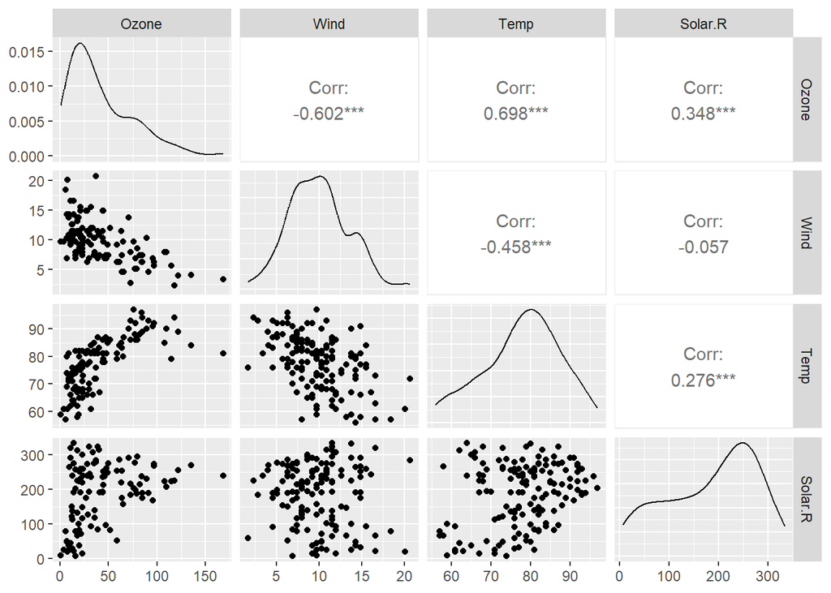

```r
#using ggally package to visualize correlation


air.tbl %>%
  select(Ozone, Wind, Temp, Solar.R) %>% #drop day and month
  ggpairs()
```

## 5.2 P4.2. Which variables are correlated highly with Ozone?

Wind and Ozone have strong negative correlation (-0.6). Hypothesis 2 is correct.  
Temp and Ozone have strong positive correlation (0.7). Hypothesis 3 is correct.

# 6 Problem 5: Examine Missing values

Where are missing values are located?

```r
colSums(is.na(air.tbl)) #convert all values to boolean, then print the sum of each column in the df
```

```
##   Ozone Solar.R    Wind    Temp   Month     Day
##      37       7       0       0       0       0
```

The number of missing values in the dataset?

```r
sum(is.na(air.tbl)) #convert all values to boolean, then sum everything contained in the vector
```

```
## [1] 44
```

The number of missing values in the Solar.R column?

```r
sum(is.na(air.tbl$Solar.R)) #convert all values in Solar R to boolean, sum everything contained in the vector
```

```
## [1] 7
```

Which rows have at least one missing value?

```r
air.tbl[!complete.cases(air.tbl),] #return rows that are NOT COMPLETE (has NA value)
```

```
## # A tibble: 42 × 6
##    Ozone Solar.R  Wind  Temp Month Day
##    <int>   <int> <dbl> <int> <fct> <fct>
##  1    NA      NA  14.3    56 May   5
##  2    28      NA  14.9    66 May   6
##  3    NA     194   8.6    69 May   10
##  4     7      NA   6.9    74 May   11
##  5    NA      66  16.6    57 May   25
##  6    NA     266  14.9    58 May   26
##  7    NA      NA   8      57 May   27
##  8    NA     286   8.6    78 June  1
##  9    NA     287   9.7    74 June  2
## 10    NA     242  16.1    67 June  3
## # ℹ 32 more rows
```

The number of rows with at least one missing value?

```r
sum(rowSums(is.na(air.tbl)) > 0) #convert all values in df to boolean, filter out FALSE, sum everything
```

```
## [1] 42
```

# 7 Problem 6: Missing value imputation

We will replace all the missing values in the Solar.R and Ozone columns with the median of the values in the relevant column.

Solar R:

```r
SolarR.median <- median(air.tbl$Solar.R, na.rm = TRUE)

air.tbl$Solar.R[is.na(air.tbl$Solar.R)] <- SolarR.median  #replace NA values in column
```

Ozone:

```r
Ozone.median <- median(air.tbl$Ozone, na.rm = TRUE)

air.tbl$Ozone[is.na(air.tbl$Ozone)] <- Ozone.median #replace NA values in column
```

We have successfully replaced NA values, confirmed by the summary function.

```r
summary(air.tbl)
```

```
##      Ozone           Solar.R           Wind             Temp
##  Min.   :  1.00   Min.   :  7.0   Min.   : 1.700   Min.   :56.00
##  1st Qu.: 21.00   1st Qu.:120.0   1st Qu.: 7.400   1st Qu.:72.00
##  Median : 31.50   Median :205.0   Median : 9.700   Median :79.00
##  Mean   : 39.56   Mean   :186.8   Mean   : 9.958   Mean   :77.88
##  3rd Qu.: 46.00   3rd Qu.:256.0   3rd Qu.:11.500   3rd Qu.:85.00
##  Max.   :168.00   Max.   :334.0   Max.   :20.700   Max.   :97.00
##
##        Month         Day
##  May      :31   1      :  5
##  June     :30   2      :  5
##  July     :31   3      :  5
##  August   :31   4      :  5
##  September:30   5      :  5
##                 6      :  5
##                 (Other):123
```

Let’s get the mean and standard deviation of all continuous variables:

```r
air.tbl %>%
  select_if(where(is.numeric)) %>% #select numeric variables
  apply(2, mean)
```

```
##      Ozone    Solar.R       Wind       Temp
##  39.558824 186.803922   9.957516  77.882353
```

```r
air.tbl %>%
  select_if(where(is.numeric)) %>% #select numeric variables
  apply(2, sd)
```

```
##     Ozone   Solar.R      Wind      Temp
## 29.054449 88.051051  3.523001  9.465270
```

# 8 Problem 7: Correlations after missing value imputation

## 8.1 P7.1. Correlation with raw Ozone

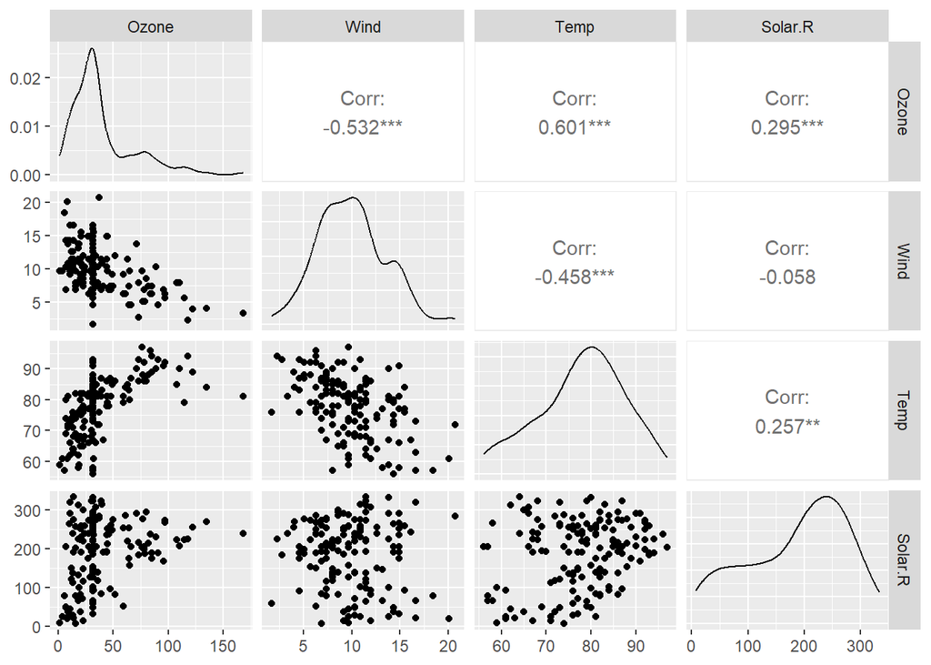

```r
air.tbl %>%
  select(Ozone, Wind, Temp, Solar.R) %>%
  ggpairs()
```

Ozone - Solar R: 0.348 -> 0.295 Ozone - Wind: -0.602 -> -0.532 Ozone- Temp: 0.698 -> 0.601

## 8.2 P7.2. Correlations with Logged Ozone

We will be putting Ozone on a log scale to normalize its distribution.

```r
air.tbl %>%
  mutate(log_Ozone = log(Ozone)) %>% #create new log variable
  select(log_Ozone, Wind, Temp, Solar.R) %>%
  cor() %>% #calculate correlation
  round(2) #round up to 2 digits
```

```
##           log_Ozone  Wind  Temp Solar.R
## log_Ozone      1.00 -0.47  0.64    0.39
## Wind          -0.47  1.00 -0.46   -0.06
## Temp           0.64 -0.46  1.00    0.26
## Solar.R        0.39 -0.06  0.26    1.00
```

Let’s see how it impacts the correlation between Ozone and others.

```r
air.tbl %>%
  select(Ozone, Wind, Temp, Solar.R) %>%
  cor() %>%
  round(2)
```

```
##         Ozone  Wind  Temp Solar.R
## Ozone    1.00 -0.53  0.60    0.30
## Wind    -0.53  1.00 -0.46   -0.06
## Temp     0.60 -0.46  1.00    0.26
## Solar.R  0.30 -0.06  0.26    1.00
```

It seems that positive correlation has increased, whereas negative correlation has decreased between Ozone and the 3 variables, after we put it on a log scale.

# 9 Problem 8: Adding a new logged Ozone variable to the data set permanently

```r
air_tbl_log <- air.tbl %>%
  mutate(log_Ozone = log(Ozone))

air_tbl_log
```

```
## # A tibble: 153 × 7
##    Ozone Solar.R  Wind  Temp Month Day   log_Ozone
##    <dbl>   <dbl> <dbl> <int> <fct> <fct>     <dbl>
##  1  41       190   7.4    67 May   1          3.71
##  2  36       118   8      72 May   2          3.58
##  3  12       149  12.6    74 May   3          2.48
##  4  18       313  11.5    62 May   4          2.89
##  5  31.5     205  14.3    56 May   5          3.45
##  6  28       205  14.9    66 May   6          3.33
##  7  23       299   8.6    65 May   7          3.14
##  8  19        99  13.8    59 May   8          2.94
##  9   8        19  20.1    61 May   9          2.08
## 10  31.5     194   8.6    69 May   10         3.45
## # ℹ 143 more rows
```

# 10 Problem 9: Data Visualization using imputed data

Since logged ozone variable is helping our analysis by normalizing the Ozone variable2s distribution, we will do our data visualization again, using this new variable instead.

## P9.1. Histogram of Ozone, Ozone_logged, and Solar.R

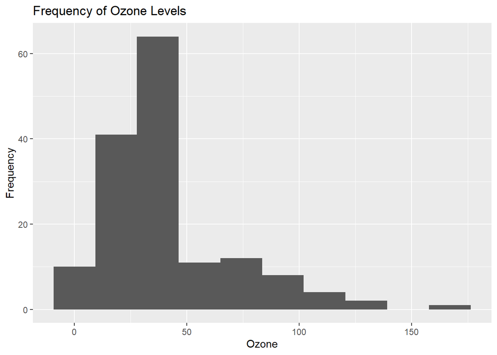

```r
air_tbl_log %>%
  ggplot(aes(Ozone)) +
  geom_histogram(bins = 10) +
  labs( title = "Frequency of Ozone Levels", y = "Frequency")
```

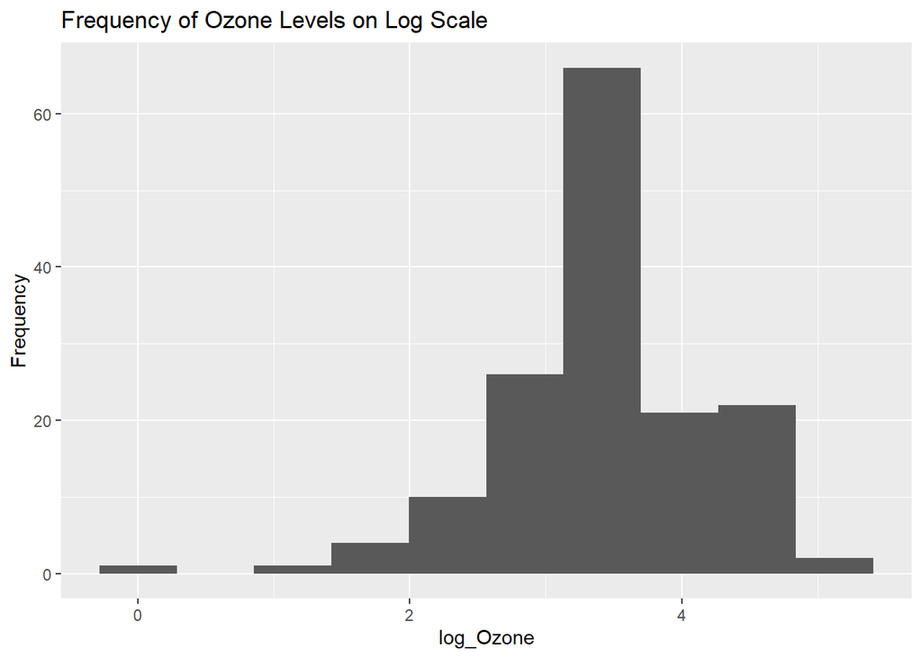

```r
air_tbl_log %>%
  ggplot(aes(log_Ozone)) +
  geom_histogram(bins = 10) +
  labs( title = "Frequency of Ozone Levels on Log Scale", y = "Frequency")
```

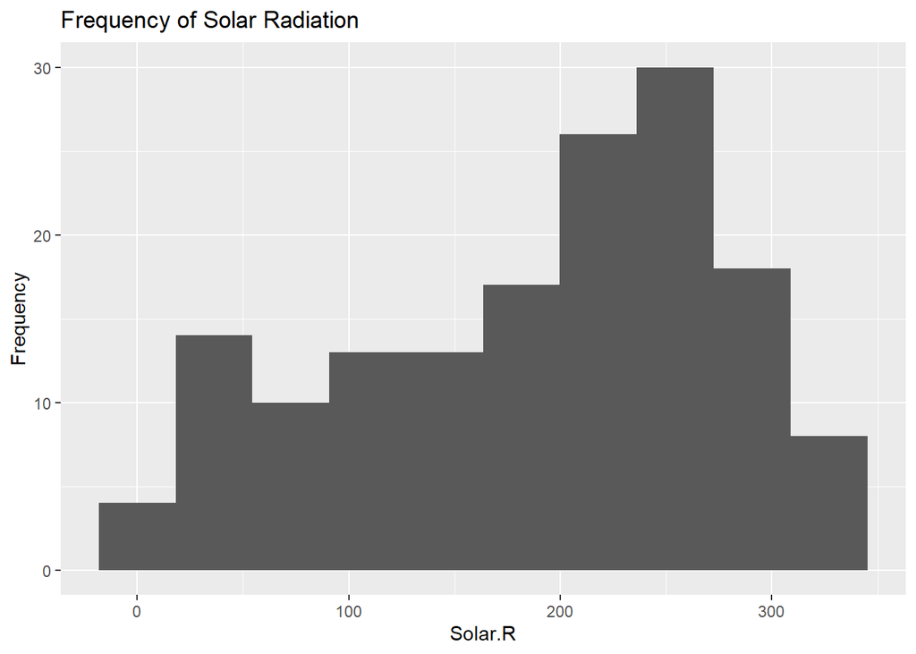

```r
air_tbl_log %>%
  ggplot(aes(Solar.R)) +
  geom_histogram(bins = 10) +
  labs( title = "Frequency of Solar Radiation", y = "Frequency")
```

## P9.2. Ozone by Continuous variables

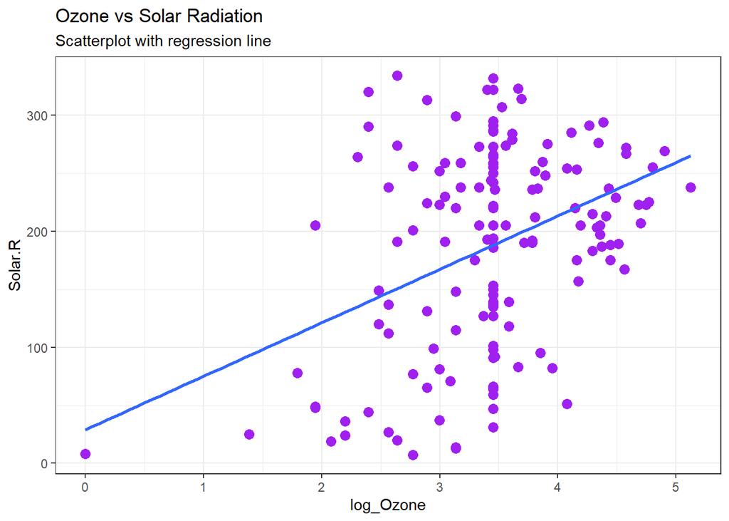

```r
air_tbl_log  %>%
ggplot(aes(log_Ozone, Solar.R)) +
  geom_point(size = 3, color = "purple") +
  geom_smooth(method = lm, se = FALSE) +
  theme_bw() +
  labs (title = "Ozone vs Solar Radiation",
        subtitle = "Scatterplot with regression line")
```

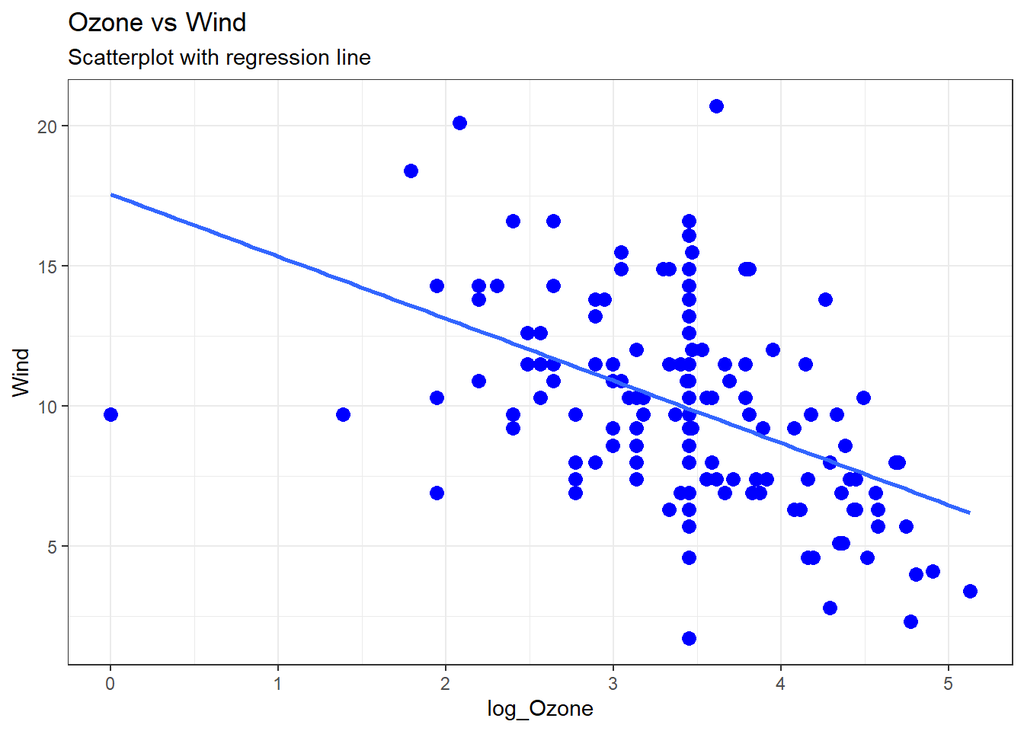

```r
air_tbl_log  %>%
ggplot(aes(log_Ozone, Wind)) +
  geom_point(size = 3, color = "blue") +
  geom_smooth(method = lm, se = FALSE) +
  theme_bw() +
  labs (title = "Ozone vs Wind",
        subtitle = "Scatterplot with regression line")
```

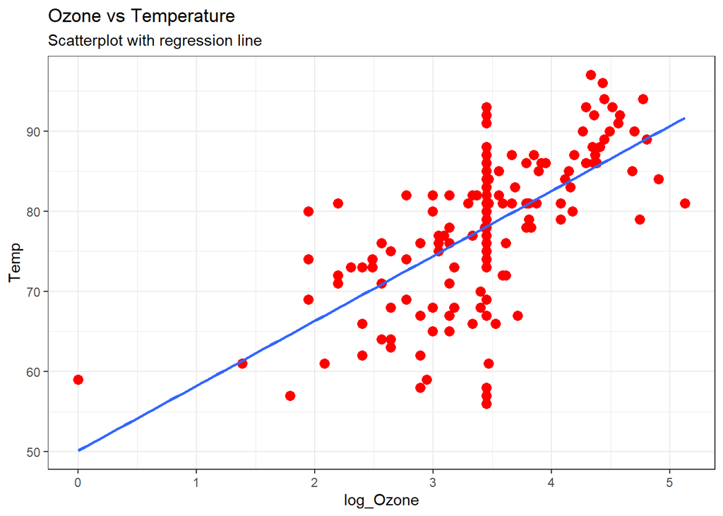

```r
air_tbl_log  %>%
ggplot(aes(log_Ozone, Temp)) +
  geom_point(size = 3, color = "red") +
  geom_smooth(method = lm, se = FALSE) +
  theme_bw() +
  labs (title = "Ozone vs Temperature",
        subtitle = "Scatterplot with regression line")
```

## P9.3. Ozone by Month

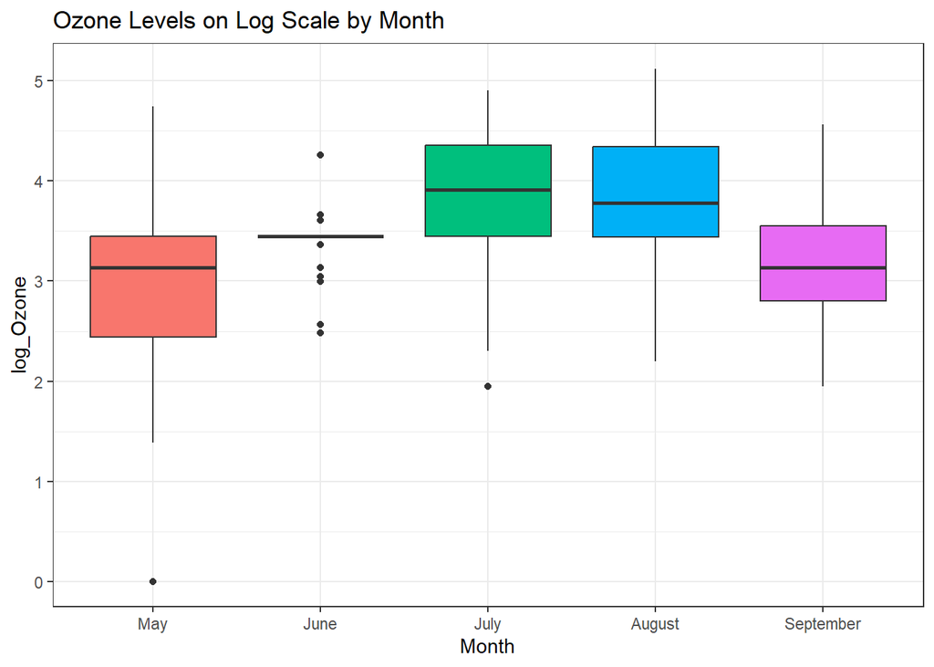

```r
air_tbl_log %>%
  ggplot(aes(Month, log_Ozone, fill = Month)) +
  geom_boxplot(show.legend = FALSE)  +
  labs( title = "Ozone Levels on Log Scale by Month") +
  theme_bw()
```

## P9.4. Moderating Role of Month in the impact of Continuous variables on Ozone

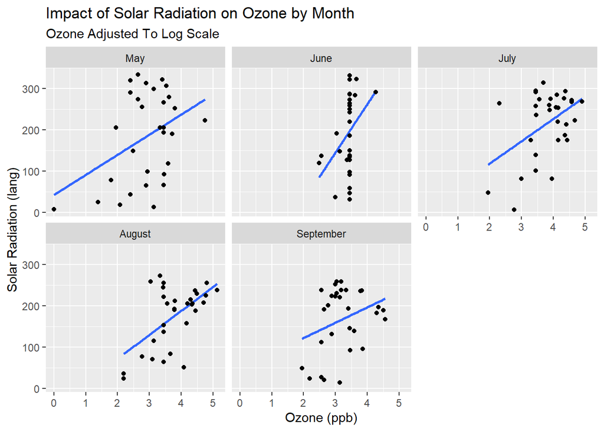

```r
air_tbl_log %>%
  select(log_Ozone, Solar.R, Month) %>%
  ggplot(aes(log_Ozone, Solar.R)) +
  facet_wrap(~Month) +
  geom_smooth(method = lm, se = FALSE) +
  geom_point() +
  labs (title = "Impact of Solar Radiation on Ozone by Month",
        subtitle = "Ozone Adjusted To Log Scale",
        y = "Solar Radiation (lang)",
        x = "Ozone (ppb)")
```

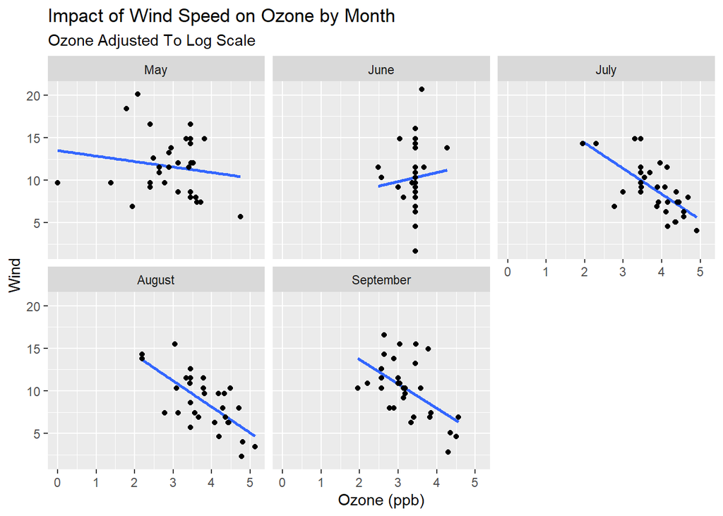

```r
air_tbl_log %>%
  select(log_Ozone, Wind, Month) %>%
  ggplot(aes(log_Ozone, Wind)) +
  facet_wrap(~Month) +
  geom_smooth(method = lm, se = FALSE) +
  geom_point() +
  labs (title = "Impact of Wind Speed on Ozone by Month",
        subtitle = "Ozone Adjusted To Log Scale",
        x = "Ozone (ppb)")
```

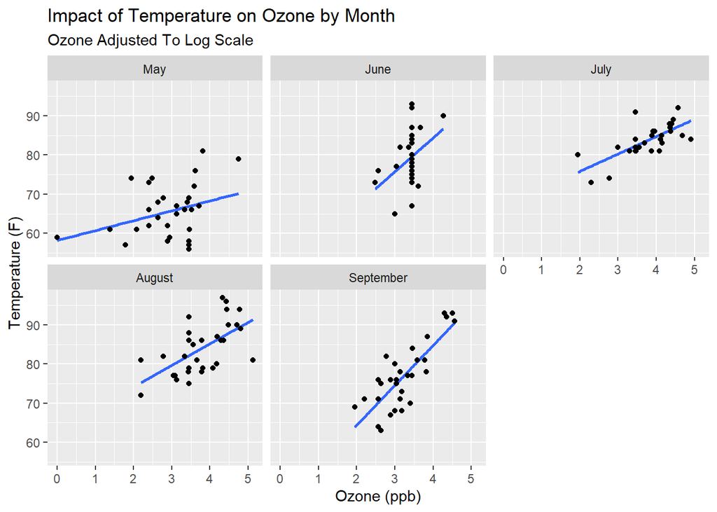

```r
air_tbl_log %>%
  select(log_Ozone, Temp , Month) %>%
  ggplot(aes(log_Ozone, Temp)) +
  facet_wrap(~Month) +
  geom_smooth(method = lm, se = FALSE) +
  geom_point() +
  labs (title = "Impact of Temperature on Ozone by Month",
        subtitle = "Ozone Adjusted To Log Scale",
        y = "Temperature (F)",
        x = "Ozone (ppb)")
```

# 11 Problem 10: Using categorical Ozone amount

## 11.1 P10.1: categorical Ozone

We will be creating a categorical Ozone variable that describes the Ozone level in the air, based on the 25th and 75th quantile.

If the Ozone of the imputed data set is less than or equal to the 25th quantile of the Ozone amount in the data, we put “Low” in the new column, if it is greater than 25th quantile and less than the 75th quantile, we put “Middle,” and if it is greater than 75th quantile, we put “high” in the new column.

```r
air_tbl_log_cat <- air_tbl_log %>%
  drop_na(Ozone) %>% #drop NAs, otherwise Ozone_cat will be "middle" where it is unknown
  mutate(Ozone_cat = case_when( Ozone <= quantile(Ozone, 1/4, na.rm = TRUE) ~ "low",
                                Ozone >= quantile(Ozone, 3/4, na.rm = TRUE) ~"high",
                                TRUE ~ "middle"),#everything ELSE that doesnt fit the above criteria
         Ozone_cat = fct_relevel(Ozone_cat, c(
           "high",
           "middle",
           "low"
         )
      )
  )

air_tbl_log_cat
```

```
## # A tibble: 153 × 8
##    Ozone Solar.R  Wind  Temp Month Day   log_Ozone Ozone_cat
##    <dbl>   <dbl> <dbl> <int> <fct> <fct>     <dbl> <fct>
##  1  41       190   7.4    67 May   1          3.71 middle
##  2  36       118   8      72 May   2          3.58 middle
##  3  12       149  12.6    74 May   3          2.48 low
##  4  18       313  11.5    62 May   4          2.89 low
##  5  31.5     205  14.3    56 May   5          3.45 middle
##  6  28       205  14.9    66 May   6          3.33 middle
##  7  23       299   8.6    65 May   7          3.14 middle
##  8  19        99  13.8    59 May   8          2.94 low
##  9   8        19  20.1    61 May   9          2.08 low
## 10  31.5     194   8.6    69 May   10         3.45 middle
## # ℹ 143 more rows
```

## 11.2 P10.2: Monthly Ozone Severity

Let’s draw a chart that shows monthly counts of each of the three levels of Ozone_cat.

```r
air_tbl_log_cat_grouped <- air_tbl_log_cat %>%
  group_by(Month, Ozone_cat) %>% #group by two variables
  count() #count the observations in each subgroup
```

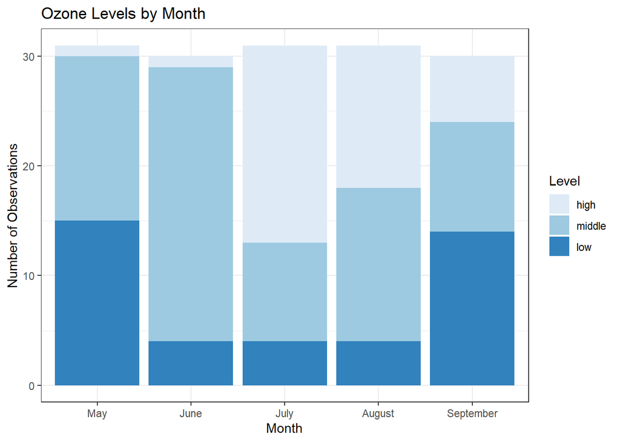

```r
air_tbl_log_cat_grouped %>%
  ggplot(aes(Month, n, fill= Ozone_cat)) +
  geom_col() +
  scale_fill_brewer(palette = "Blues") + #color levels by shade
  labs (title = "Ozone Levels by Month",
        y = "Number of Observations",
        fill = "Level") +
  theme_bw()
```

## 11.3 P10.3: Insights from the chart

The number of days when “high” level of Ozone was present in the atmosphere is significantly higher in July and August.

```r
air.tbl %>%
  group_by(Month) %>%
  summarise(avg_temp = mean(Temp))
```

```
## # A tibble: 5 × 2
##   Month     avg_temp
##   <fct>        <dbl>
## 1 May           65.5
## 2 June          79.1
## 3 July          83.9
## 4 August        84.0
## 5 September     76.9
```

We already know Ozone correlates highly with temperature from Problem 2 and Problem 3. So it isn’t a surprise to see higher Ozone levels being more prevalent in the months with the highest average temperature.

# 12 Conclusion

Based on our analysis, all of our hypothesis on the relationship between Ozone and other independent variables have been confirmed as correct.

H1: Ozone amount will be associated positively with Solar radiation amount (Solar.R)  
H2: Ozone amount will be associated negatively with Wind speed (Wind)  
H3: Ozone amount will be associated positively with Maximum daily temperature (Temp)  
H4: Ozone amount will be highest during summer months.